# F₂ QTL Scans — All Phenotypes

- Show All Code
- Hide All Code
- View Source

QTL series notebook 3 — scanone across 14 traits with per-trait genome-wide permutation thresholds

Author

Fausto Rodriguez Zapata

Published

July 31, 2026

**QTL series — notebook 3.** Uses the map from notebook 2; marker QC and encoding are in notebook 1.

**Note**

**Public data only.** Scan results — LOD by position and the per-trait permutation thresholds — are published as `data/f2_qtl_scan_summary.tsv` and `data/f2_qtl_scan_profiles.tsv`. No individual genotypes or phenotypes are included, and everything below is reproduced from those two files.

# 1 Method

Every phenotype was scanned with `scanone` on the 1,152-marker map at a 1 cM pseudomarker step, with `error.prob = 0.01` in `calc.genoprob` to match the value the map was built at (measured immaterial at scan time: *r* = 0.998 against 2.5 × 10⁻³ across 3,005 positions).

Thresholds are **per-trait**, from 1,000 permutations each — not a shared threshold, since the permutation distribution depends on the trait’s own distribution. `PAPP` is an ordinal 1–4 score and was scanned non-parametrically (`model = "np"`); everything else used the normal model.

## 1.1 The code that ran the scans

`scripts/qtl/scan_all_traits.R`, inserted from the script itself at render time so what is shown here cannot drift from what actually ran. The `scanone` and permutation calls, the model choice per trait, and the support-interval computation are all in it.

**scripts/qtl/scan_all_traits.R — the scan itself**

```r
#!/usr/bin/env Rscript
# =============================================================================
# scanone for every F2 phenotype, with per-trait permutation thresholds.
#
#   Rscript agent/scan_all_traits.R 2>&1 | tee agent/scan_all_traits.log
#
# error.prob = 0.01 throughout, matching the map (measured immaterial at scan time:
# r = 0.9978 vs 2.5e-3, agent/scan_pue_errorprob.log).
#
# PAPP is an ordinal 1-4 score, so it is scanned with model = "np" (Kruskal-Wallis);
# everything else uses the normal model. Normality is REPORTED per trait because
# several of these are strongly skewed and that inflates permutation thresholds.
#
# Multiple traits are scanned, so a per-trait 5% threshold is NOT a 5% experiment-wide
# rate. The trait-corrected threshold is reported alongside.
# =============================================================================

suppressMessages({library(qtl); library(data.table)})
rule <- function(x) cat("\n", strrep("=", 78), "\n", x, "\n", strrep("=", 78), "\n", sep = "")

D <- "data/qtl/derived"
ERROR_PROB <- 0.01; N_PERM <- 1000; STEP <- 1
NCLUST <- min(8L, parallel::detectCores())
set.seed(1)

cr <- readRDS(file.path(D, "rqtl_cross_map_teonamqc.rds"))
info <- fread(file.path(D, "abh_all_marker_info.tsv"), colClasses = list(character = "chr_v5"))
crx <- calc.genoprob(cr, step = STEP, error.prob = ERROR_PROB, map.function = "haldane")
mp <- pull.map(cr)

TRAITS <- setdiff(names(cr$pheno), "id")
NP <- "PAPP"                      # ordinal
cat(sprintf("map: %d markers, %.1f cM | traits: %s\n", totmar(cr),
            sum(sapply(mp, function(v) max(v) - min(v))), paste(TRAITS, collapse = " ")))

mb_at <- function(chr, cm) {
  v <- mp[[chr]]
  as.numeric(approx(v, info$ref_pos[match(names(v), info$marker)], xout = cm, rule = 2)$y) / 1e6
}

rows <- list(); prof <- list()
for (tr in TRAITS) {
  model <- if (tr %in% NP) "np" else "normal"
  y <- cr$pheno[[tr]]
  n_ok <- sum(!is.na(y))
  if (n_ok < 50 || length(unique(y[!is.na(y)])) < 3) {
    cat(sprintf("%-6s SKIPPED (n = %d, %d distinct values)\n", tr, n_ok,
                length(unique(y[!is.na(y)]))))
    next
  }
  sw <- if (model == "normal") shapiro.test(y[!is.na(y)])$p.value else NA_real_
  sc <- scanone(crx, pheno.col = tr, model = model)
  pm <- scanone(crx, pheno.col = tr, model = model, n.perm = N_PERM,
                n.cluster = NCLUST, verbose = FALSE)
  th <- summary(pm, alpha = c(0.05, 0.10))[, 1]
  i  <- which.max(sc$lod)
  pk_chr <- as.character(sc$chr[i]); pk_cm <- sc$pos[i]; pk_lod <- sc$lod[i]

  # contiguous 1.5-LOD interval around the peak
  scc <- as.data.table(sc)[as.character(chr) == pk_chr][order(pos)]
  j <- which.max(scc$lod); cut <- pk_lod - 1.5
  lo <- j; while (lo > 1 && scc$lod[lo - 1] >= cut) lo <- lo - 1
  hi <- j; while (hi < nrow(scc) && scc$lod[hi + 1] >= cut) hi <- hi + 1

  rows[[length(rows) + 1L]] <- data.table(
    trait = tr, model = model, n = n_ok, shapiro_p = signif(sw, 3),
    peak_chr = pk_chr, peak_cM = round(pk_cm, 1),
    peak_Mb = round(mb_at(pk_chr, pk_cm), 2), lod = round(pk_lod, 3),
    thr05 = round(th[1], 3), thr10 = round(th[2], 3),
    sig05 = pk_lod >= th[1], sig10 = pk_lod >= th[2],
    ci_lo_cM = round(scc$pos[lo], 1), ci_hi_cM = round(scc$pos[hi], 1),
    ci_lo_Mb = round(mb_at(pk_chr, scc$pos[lo]), 2),
    ci_hi_Mb = round(mb_at(pk_chr, scc$pos[hi]), 2))
  d <- as.data.table(sc); d[, `:=`(trait = tr, chr = as.character(chr))]
  prof[[length(prof) + 1L]] <- d
  r <- rows[[length(rows)]]
  cat(sprintf("%-6s %-6s n=%3d | peak chr%-2s %6.1f cM (%7.2f Mb) LOD %5.3f | thr05 %5.3f | %s\n",
              tr, model, n_ok, r$peak_chr, r$peak_cM, r$peak_Mb, r$lod, r$thr05,
              ifelse(r$sig05, "SIGNIFICANT", ifelse(r$sig10, "suggestive", "-"))))
}
res <- rbindlist(rows); pr <- rbindlist(prof)

rule("SUMMARY — all traits, ranked by LOD")
print(res[order(-lod), .(trait, model, n, peak_chr, peak_cM, peak_Mb, lod,
                         thr05, sig05, sig10)])

rule("TRAIT-CORRECTED SIGNIFICANCE")
k <- nrow(res)
cat(sprintf("%d traits scanned. A per-trait 5%% threshold gives an experiment-wide\n", k))
cat(sprintf("false-positive rate of 1-0.95^%d = %.1f%% if the traits were independent.\n",
            k, 100 * (1 - 0.95^k)))
cat("They are NOT independent -- several are arithmetic functions of others\n")
cat("(GY, HI, PUE, RSR, RYE, TDM), so the true rate is between 5% and that figure.\n")
cat(sprintf("\nBonferroni-corrected per-trait alpha: %.4f\n", 0.05 / k))
res[, sig05_bonf := lod >= thr05 + log10(k)]   # crude: shift on the LOD scale
print(res[sig05 == TRUE | sig10 == TRUE,
          .(trait, peak_chr, peak_Mb, lod, thr05, sig05, sig10)])

rule("SUPPORT INTERVALS FOR ANYTHING SUGGESTIVE OR BETTER")
hits <- res[sig10 == TRUE]
if (nrow(hits)) print(hits[, .(trait, peak_chr, peak_cM, lod,
                               ci_lo_cM, ci_hi_cM, ci_lo_Mb, ci_hi_Mb,
                               width_Mb = round(ci_hi_Mb - ci_lo_Mb, 1))])
if (!nrow(hits)) cat("nothing reaches even the 10% genome-wide threshold.\n")

rule("OUTPUT")
fwrite(res, "output/qtl/scan_all_summary.tsv", sep = "\t")
fwrite(pr,  "output/qtl/scan_all_profiles.tsv", sep = "\t")
cat("wrote output/qtl/scan_all_{summary,profiles}.tsv\n")

# PUBLIC. data/qtl/ is gitignored (raw genotypes), so the scan RESULTS -- no individual
# data, just LOD by position and the per-trait permutation thresholds -- go to a tracked
# path alongside data/f2_genetic_map.tsv.
pub <- copy(res)
setnames(pub, "thr05", "perm_thr_0.05"); setnames(pub, "thr10", "perm_thr_0.10")
fwrite(pub, "data/f2_qtl_scan_summary.tsv", sep = "\t")
prp <- copy(pr)[, .(trait, chr, pos_cM = round(pos, 2), lod = round(lod, 4))]
fwrite(prp, "data/f2_qtl_scan_profiles.tsv", sep = "\t")
cat(sprintf("wrote data/f2_qtl_scan_summary.tsv (%d traits) and\n", nrow(pub)))
cat(sprintf("      data/f2_qtl_scan_profiles.tsv (%d positions x trait)\n", nrow(prp)))
```

For a single trait with effect estimates and a `fitqtl` summary, `scripts/qtl/scan_trait.R`:

**scripts/qtl/scan_trait.R — one trait, with effects**

```r
#!/usr/bin/env Rscript
# =============================================================================
# Single-trait scanone on the current map, with permutation thresholds and
# physically-anchored support intervals.
#
#   TRAIT=TDM Rscript agent/scan_trait.R 2>&1 | tee agent/scan_TDM.log
#
# error.prob is 0.01, matching the map. Measured to be immaterial at scan time:
# 0.01 vs 2.5e-3 gave r = 0.9978 across 3,005 positions, mean dLOD +0.009
# (agent/scan_pue_errorprob.log), so no comparison arm is run here.
#
# Support intervals are reported in cM AND in CML530 Mb. The cM width is inflated with
# the map (~1,858 cM against a ~1,550 expectation); the Mb interval is not, and is what
# a candidate-gene search should use.
# =============================================================================

suppressMessages({library(qtl); library(data.table); library(ggplot2)})
rule <- function(x) cat("\n", strrep("=", 78), "\n", x, "\n", strrep("=", 78), "\n", sep = "")

D       <- "data/qtl/derived"
TRAIT   <- Sys.getenv("TRAIT", "TDM")
MODEL   <- Sys.getenv("MODEL", "normal")   # "np" for ordinal traits such as PAPP
ERROR_PROB <- 0.01
N_PERM  <- 1000
STEP    <- 1
NCLUST  <- min(8L, parallel::detectCores())
set.seed(1)

cr <- readRDS(file.path(D, "rqtl_cross_map_teonamqc.rds"))
info <- fread(file.path(D, "abh_all_marker_info.tsv"), colClasses = list(character = "chr_v5"))
stopifnot(TRAIT %in% names(cr$pheno))

rule(sprintf("1. INPUT — %s, model %s", TRAIT, MODEL))
y <- cr$pheno[[TRAIT]]
cat(sprintf("map: %d markers, %.1f cM, %d individuals\n", totmar(cr),
            sum(sapply(pull.map(cr), function(v) max(v) - min(v))), nind(cr)))
cat(sprintf("%s: n = %d non-missing of %d\n", TRAIT, sum(!is.na(y)), length(y)))
print(round(summary(y), 4))
if (MODEL == "normal") {
  sw <- shapiro.test(y[!is.na(y)])
  cat(sprintf("Shapiro-Wilk W = %.4f, p = %.3g  (normality of the raw trait)\n",
              sw$statistic, sw$p.value))
}

rule("2. SCAN + PERMUTATION")
crx <- calc.genoprob(cr, step = STEP, error.prob = ERROR_PROB, map.function = "haldane")
sc  <- scanone(crx, pheno.col = TRAIT, model = MODEL)
pm  <- scanone(crx, pheno.col = TRAIT, model = MODEL, n.perm = N_PERM,
               n.cluster = NCLUST, verbose = FALSE)
th  <- summary(pm, alpha = c(0.05, 0.10, 0.63))[, 1]
cat(sprintf("permutations: %d\n", N_PERM))
cat(sprintf("genome-wide thresholds: 5%% = %.3f   10%% = %.3f   63%% = %.3f\n",
            th[1], th[2], th[3]))

rule("3. PEAK PER CHROMOSOME")
pk <- as.data.table(sc)[, .(pos = pos[which.max(lod)], lod = max(lod)),
                        by = .(chr = as.character(chr))]
pk[, sig := fifelse(lod >= th[1], "** 0.05", fifelse(lod >= th[2], "*  0.10",
             fifelse(lod >= th[3], ".  0.63", "")))]
print(pk[order(-lod)][, .(chr, pos = round(pos, 1), lod = round(lod, 3), sig)])

rule("4. PEAKS ABOVE THE 63% THRESHOLD, WITH SUPPORT INTERVALS")
mp <- pull.map(cr)
mb_of <- function(chr, cm_lo, cm_hi) {
  v <- mp[[chr]]
  inr <- names(v)[v >= cm_lo & v <= cm_hi]
  if (!length(inr)) inr <- names(sort(abs(v - (cm_lo + cm_hi)/2)))[1]
  p <- info[marker %in% inr, ref_pos]
  c(min(p)/1e6, max(p)/1e6, length(inr))
}
hits <- pk[lod >= th[3]][order(-lod)]
if (!nrow(hits)) cat("nothing reaches even the 63% threshold.\n")
res <- list()
for (i in seq_len(nrow(hits))) {
  ch <- hits$chr[i]
  li <- lodint(sc, chr = ch, drop = 1.5, expandtomarkers = TRUE)
  mb <- mb_of(ch, min(li$pos), max(li$pos))
  # variance explained, from the single-QTL fit at the peak
  qc <- makeqtl(crx, chr = ch, pos = hits$pos[i], what = "prob")
  fq <- fitqtl(crx, pheno.col = TRAIT, qtl = qc, method = "hk", get.ests = TRUE)
  pve <- summary(fq)$result.full["Model", "%var"]
  res[[i]] <- data.table(chr = ch, peak_cM = round(hits$pos[i], 1),
                         lod = round(hits$lod[i], 3),
                         ci_lo_cM = round(min(li$pos), 1), ci_hi_cM = round(max(li$pos), 1),
                         width_cM = round(diff(range(li$pos)), 1),
                         ci_lo_Mb = round(mb[1], 2), ci_hi_Mb = round(mb[2], 2),
                         width_Mb = round(mb[2] - mb[1], 2), markers_in_ci = mb[3],
                         pct_var = round(pve, 2), sig = hits$sig[i])
}
if (length(res)) { out <- rbindlist(res); print(out) }

rule("5. TOP PEAK — nearest markers and effect")
top <- pk[which.max(lod)]
v <- mp[[top$chr]]
near <- names(sort(abs(v - top$pos)))[1:3]
print(info[marker %in% near, .(marker = substr(marker, 1, 22), cml_chr,
                               Mb = round(ref_pos/1e6, 2), v5chr = chr_v5,
                               v5_Mb = round(pos_v5/1e6, 2), maf = round(maf, 3))])
qc <- makeqtl(crx, chr = top$chr, pos = top$pos, what = "prob")
fq <- fitqtl(crx, pheno.col = TRAIT, qtl = qc, method = "hk", get.ests = TRUE)
print(summary(fq))

rule("6. OUTPUT")
dt <- as.data.table(sc); dt[, chr := as.character(chr)]
fwrite(dt, sprintf("output/qtl/scan_%s.tsv", TRAIT), sep = "\t")
dt[, chrf := factor(chr, levels = as.character(1:10))]
p <- ggplot(dt, aes(pos, lod)) +
  geom_line(linewidth = 0.4, colour = "grey20") +
  geom_hline(yintercept = th[1], linetype = "dashed", colour = "firebrick") +
  geom_hline(yintercept = th[2], linetype = "dotted", colour = "grey40") +
  facet_grid(~chrf, scales = "free_x", space = "free_x") +
  labs(x = "position (cM)", y = "LOD",
       title = sprintf("%s — scanone, error.prob %.3g, %d permutations",
                       TRAIT, ERROR_PROB, N_PERM),
       subtitle = sprintf("dashed = 5%% genome-wide (%.2f), dotted = 10%% (%.2f)",
                          th[1], th[2])) +
  theme_bw(base_size = 11) + theme(panel.spacing.x = unit(0.05, "lines"))
ggsave(sprintf("output/qtl/scan_%s.png", TRAIT), p, width = 12, height = 4, dpi = 150, bg = "white")
cat(sprintf("wrote output/qtl/scan_%s.{tsv,png}\n", TRAIT))
```

## 1.2 Reading the results back

The chunks below re-plot the published output; they do **not** re-run the scans.

```r
library(data.table)
library(ggplot2)
library(knitr)
res <- fread("data/f2_qtl_scan_summary.tsv")
pr  <- fread("data/f2_qtl_scan_profiles.tsv")
theme_set(theme_bw(base_size = 11))
```

# 2 Results by trait

```r
setorder(res, -lod)
kable(res[, .(trait, model, n, shapiro_p,
              chr = peak_chr, `peak cM` = peak_cM, `peak Mb` = peak_Mb,
              LOD = lod, `thr 5%` = `perm_thr_0.05`, `thr 10%` = `perm_thr_0.10`,
              `sig 5%` = fifelse(sig05, "yes", ""),
              `sig 10%` = fifelse(sig10, "yes", ""))],
      caption = "Peak LOD per trait against its own 1,000-permutation genome-wide threshold. Ranked by LOD.")
```

Table 1: Peak LOD per trait against its own 1,000-permutation genome-wide threshold. Ranked by LOD.

| trait | model | n | shapiro_p | chr | peak cM | peak Mb | LOD | thr 5% | thr 10% | sig 5% | sig 10% |
| --- | --- | --- | --- | --- | --- | --- | --- | --- | --- | --- | --- |
| EW | normal | 166 | 2.72e-01 | 1 | 219.1 | 287.78 | 4.107 | 3.921 | 3.513 | yes | yes |
| PH | normal | 166 | 1.98e-04 | 5 | 78.5 | 19.61 | 3.908 | 3.849 | 3.538 | yes | yes |
| HI | normal | 166 | 5.68e-02 | 5 | 166.2 | 219.84 | 3.812 | 3.789 | 3.451 | yes | yes |
| RSR | normal | 166 | 1.10e-06 | 9 | 98.0 | 148.71 | 3.788 | 3.904 | 3.574 |  | yes |
| GY | normal | 166 | 4.35e-01 | 1 | 146.7 | 213.46 | 3.547 | 3.791 | 3.485 |  | yes |
| GYPP | normal | 166 | 4.35e-01 | 1 | 146.7 | 213.46 | 3.547 | 3.814 | 3.444 |  | yes |
| PUE | normal | 166 | 4.35e-01 | 1 | 146.7 | 213.46 | 3.547 | 3.766 | 3.488 |  | yes |
| SW | normal | 166 | 1.00e-07 | 2 | 171.7 | 217.82 | 3.086 | 3.880 | 3.508 |  |  |
| TDM | normal | 166 | 1.00e-07 | 2 | 171.7 | 217.82 | 2.983 | 3.775 | 3.445 |  |  |
| EH | normal | 166 | 1.62e-01 | 10 | 145.4 | 151.33 | 2.786 | 3.874 | 3.486 |  |  |
| PAPP | np | 166 | NA | 2 | 29.1 | 6.93 | 2.745 | 3.523 | 3.291 |  |  |
| SD | normal | 166 | 2.00e-07 | 2 | 171.7 | 217.82 | 2.688 | 3.745 | 3.444 |  |  |
| RYE | normal | 166 | 1.63e-03 | 5 | 42.0 | 6.84 | 2.581 | 3.918 | 3.491 |  |  |
| RW | normal | 166 | 0.00e+00 | 2 | 171.7 | 217.82 | 1.802 | 3.874 | 3.534 |  |  |

```r
cat(sprintf("traits scanned: %d\n", nrow(res)))
```

```
traits scanned: 14
```

```r
cat(sprintf("clearing their own 5%% genome-wide threshold : %d (%s)\n",
            sum(res$sig05), paste(res[sig05 == TRUE, trait], collapse = ", ")))
```

```
clearing their own 5% genome-wide threshold : 3 (EW, PH, HI)
```

```r
cat(sprintf("clearing 10%% but not 5%%                     : %d (%s)\n",
            sum(res$sig10 & !res$sig05),
            paste(res[sig10 == TRUE & sig05 == FALSE, trait], collapse = ", ")))
```

```
clearing 10% but not 5%                     : 4 (RSR, GY, GYPP, PUE)
```

# 3 Scan profiles

Dashed line is each trait’s own 5 % genome-wide threshold.

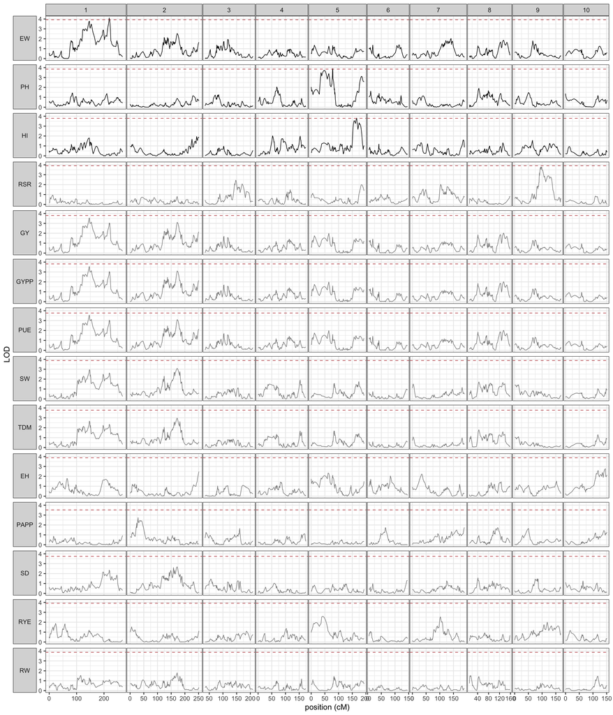

Figure 1: scanone profiles for all traits. Each panel carries its own permutation threshold.

```r
pr[, chrf := factor(chr, levels = 1:10)]
pr <- merge(pr, res[, .(trait, thr = `perm_thr_0.05`, sig05)], by = "trait")
pr[, trait := factor(trait, levels = res$trait)]
ggplot(pr, aes(pos_cM, lod)) +
  geom_line(aes(colour = sig05), linewidth = 0.35) +
  geom_hline(aes(yintercept = thr), linetype = "dashed",
             colour = "firebrick", linewidth = 0.3) +
  facet_grid(trait ~ chrf, scales = "free_x", space = "free_x", switch = "y") +
  scale_colour_manual(values = c(`TRUE` = "black", `FALSE` = "grey55"), guide = "none") +
  labs(x = "position (cM)", y = "LOD") +
  theme(panel.spacing.x = unit(0.04, "lines"),
        strip.text.y.left = element_text(angle = 0), strip.placement = "outside")
```

# 4 The traits that clear their own threshold

```r
hits <- res[sig05 == TRUE][order(-lod)]
kable(hits[, .(trait, chr = peak_chr, `peak Mb` = peak_Mb, LOD = lod,
               `thr 5%` = `perm_thr_0.05`,
               margin = round(lod - `perm_thr_0.05`, 3),
               `CI Mb` = paste0(ci_lo_Mb, "–", ci_hi_Mb),
               `CI width Mb` = round(ci_hi_Mb - ci_lo_Mb, 1))],
      caption = "Traits above their own 5% genome-wide threshold, with 1.5-LOD support intervals in CML530 megabases.")
```

Table 2: Traits above their own 5% genome-wide threshold, with 1.5-LOD support intervals in CML530 megabases.

| trait | chr | peak Mb | LOD | thr 5% | margin | CI Mb | CI width Mb |
| --- | --- | --- | --- | --- | --- | --- | --- |
| EW | 1 | 287.78 | 4.107 | 3.921 | 0.186 | 286.38–291.24 | 4.9 |
| PH | 5 | 19.61 | 3.908 | 3.849 | 0.059 | 17.06–30.61 | 13.6 |
| HI | 5 | 219.84 | 3.812 | 3.789 | 0.023 | 215.97–223.4 | 7.4 |

**EW** (ear weight) is the strongest signal and by far the best localised — a 4.9 Mb support interval on chr1, against 13.6 Mb for PH and 7.4 Mb for HI. **PH** (plant height) peaks on chr5 at 19.6 Mb with a dominance-driven effect (*d* = 9.76 ± 2.46 against *a* = 3.82 ± 1.78). **HI** clears by 0.023 LOD.

## 4.1 Correlated traits share peaks by construction

```r
kable(res[order(peak_chr, peak_cM),
          .(trait, chr = peak_chr, `peak cM` = peak_cM, LOD = lod)][
          `peak cM` %in% res[, .N, by = peak_cM][N > 1, peak_cM]],
      caption = "Traits peaking at identical map positions. These are not independent observations.")
```

Table 3: Traits peaking at identical map positions. These are not independent observations.

| trait | chr | peak cM | LOD |
| --- | --- | --- | --- |
| GY | 1 | 146.7 | 3.547 |
| GYPP | 1 | 146.7 | 3.547 |
| PUE | 1 | 146.7 | 3.547 |
| SW | 2 | 171.7 | 3.086 |
| TDM | 2 | 171.7 | 2.983 |
| SD | 2 | 171.7 | 2.688 |
| RW | 2 | 171.7 | 1.802 |

# 5 Nothing survives correction for 14 traits

```r
k <- nrow(res)
cat(sprintf("traits scanned: %d\n", k))
```

```
traits scanned: 14
```

```r
cat(sprintf("expected traits clearing a per-trait 5%% threshold by chance: %.1f\n", 0.05 * k))
```

```
expected traits clearing a per-trait 5% threshold by chance: 0.7
```

```r
cat(sprintf("observed: %d\n", sum(res$sig05)))
```

```
observed: 3
```

```r
cat(sprintf("P(at least one false positive) if traits were independent: %.1f%%\n",
            100 * (1 - 0.95^k)))
```

```
P(at least one false positive) if traits were independent: 51.2%
```

```r
kable(hits[, .(trait, LOD = lod, `thr 5%` = `perm_thr_0.05`,
               margin = round(lod - `perm_thr_0.05`, 3))],
      caption = "How much room the significant traits actually have.")
```

Table 4: How much room the significant traits actually have.

| trait | LOD | thr 5% | margin |
| --- | --- | --- | --- |
| EW | 4.107 | 3.921 | 0.186 |
| PH | 3.908 | 3.849 | 0.059 |
| HI | 3.812 | 3.789 | 0.023 |

Three traits clear their own 5 % genome-wide threshold. That is the correct threshold for **one** trait tested in isolation — it is not the right one here, because 14 traits were scanned.

- Under the null, **0.7 traits** would be expected to clear a per-trait 5 % threshold by chance. Three were observed, but the margins are **0.186, 0.059 and 0.023 LOD** — all three sit essentially on the line.
- The traits are **not independent**, so neither the naive 51 % family-wise error rate nor a plain Bonferroni correction is right. The true rate lies between 5 % and 51 %.
- Under any correction for 14 traits — Bonferroni gives a per-trait α of 0.0036 — **none of the three survives.**

**ImportantConclusion**

**No QTL in this experiment survives correction for the number of traits scanned.** Three traits reach their individual 5 % genome-wide thresholds, but by margins of 0.02–0.19 LOD, in a set of 14 correlated traits where ~0.7 such results are expected by chance.

Localisation is a separate question from significance, and the intervals should be read on their own terms. Counted against the CML530 annotation:

| trait | interval | width | protein-coding genes |
| --- | --- | --- | --- |
| EW | chr1:286.38–291.24 Mb | 4.9 Mb | **124** |
| HI | chr5:215.97–223.40 Mb | 7.4 Mb | 329 |
| PH | chr5:17.06–30.61 Mb | 13.6 Mb | 283 |
| GY / GYPP / PUE | chr1:202.00–259.45 Mb | 57.5 Mb | 1,165 |

EW’s 124-gene interval is a workable starting point for a candidate search — that is a normal first-pass F₂ resolution, not a dead end. The 57 Mb suggestive intervals are not. What limits EW is therefore **not** its localisation but its significance: a 0.186 LOD margin in a 14-trait experiment.

This is a property of the **experiment**, not of the map. With 166 phenotyped plants the detection floor is roughly 8–10 % of phenotypic variance, and the two most heritable traits in the parallel diallel — days to anthesis and silking, h² ≈ 0.60 with Baker’s ratio ≈ 0.98, i.e. almost purely additive — **were never scored on these plants**. The best F₂-mappable trait available is TDM at h² = 0.266, and PUE, the trait of interest, is the least heritable of all at h² = 0.028.

# 6 What would change the answer

- **Phenotype flowering time on the F₂**, or on F₂:₃ rows if seed was kept. h² ≈ 0.60 and near-pure additivity is a completely different proposition from h² = 0.03.
- **Replicated F₂:₃ families.** One season, no new genotyping, and replication would cut the residual variance that currently sets the detection floor.
- **More plants.** At n = 166 the floor is ~8–10 % PVE; QTL below that are undetectable regardless of map quality.

Improving the map further will not help. At one marker per 1.9 Mb it already resolves far finer than 372 meioses can exploit.

# 7 Data availability

| file | contents |
| --- | --- |
| `data/f2_qtl_scan_summary.tsv` | one row per trait: peak position, LOD, permutation thresholds, support interval |
| `data/f2_qtl_scan_profiles.tsv` | LOD at every scan position for every trait |
| `data/f2_genetic_map.tsv` | the map the scans were run on |

Scripts: `scripts/qtl/scan_all_traits.R` (all traits), `scripts/qtl/scan_trait.R` (one trait, with effect estimates). Protocol: `scripts/qtl/PROTOCOL.md`.